# Google_Job_Analysis

Alissa Munerato

10/30/2019

## Todas as áreas

Ao explorar o dataset, percebe-se que as vagas oferecem padrões de escrita. A primeira oportunidade encontrada ao analisar as qualidades mínimas necessárias para o Google, é o fato de uma grande quantia especificar os anos de experiência necessários para os candidatos.

Dessa maneira, foi possível quantificar a experiência necessária nas 12 maiores categorias:

```r
setwd("~/Analysis/")

# necessary libraries
library(tidyverse)
library(tidytext)
library(formattable)

# loads dataset
df <- readxl::read_excel("~/Analysis/job_skills.xlsx")
```

```r
colnames(df) <- c("company", "title", "category", "location",
                  "responsibilities", "minimumQualifications",
                  "preferredQualifications")

# Experience on Categories -------------------------------------------------

# Minimum Qualifications on Categories
dfMinQual <- df[,c("company", "title", "category", "location", "minimumQualifications")]
dfMinQual <- separate_rows(dfMinQual,"minimumQualifications", sep = "\n")

# Testing for data homogeneity
dfMinQual <- dfMinQual[str_detect(dfMinQual$minimumQualifications, regex("experience", ignore_case = TRUE)),]

# How many years of experience are necessary for these jobs?
dfMinQual$necessaryYears <- str_extract(dfMinQual$minimumQualifications, "[0-9]*")
dfMinQual$necessaryYears[dfMinQual$necessaryYears == ""] <- "Undefined"

# Calculating how many times specific years were mentioned
dfMinQualPlot <- dfMinQual[,c("category", "necessaryYears")]
dfMinQualPlot <- dfMinQualPlot %>%
  group_by(category, necessaryYears) %>%
  add_tally() %>%
  unique()

# Filtering rows in which experience wasn't necessary or was undefined
dfMinQualPlot <- dfMinQualPlot[dfMinQualPlot$necessaryYears != "Undefined",]

# Preparing for dataviz
dfMinQualPlot2 <- dfMinQualPlot %>%
  group_by(category) %>%
  summarise(n = sum(n)) %>%
  arrange(desc(n)) %>%
  ungroup()

# Classifying top 12
top12 <- head(dfMinQualPlot2$category, 12)

dfMinQualPlot <- dfMinQualPlot[dfMinQualPlot$category %in% top12,]

dfMinQualPlot$category <- factor(dfMinQualPlot$category, levels = top12)

dfMinQualPlot <- arrange(dfMinQualPlot, category)

dfMinQualPlot$n <- as.numeric(dfMinQualPlot$n)
colnames(dfMinQualPlot) <- c("category", "necessaryYears", "numberOfTimes")
dfMinQualPlot$necessaryYears <- as.numeric(dfMinQualPlot$necessaryYears)
```

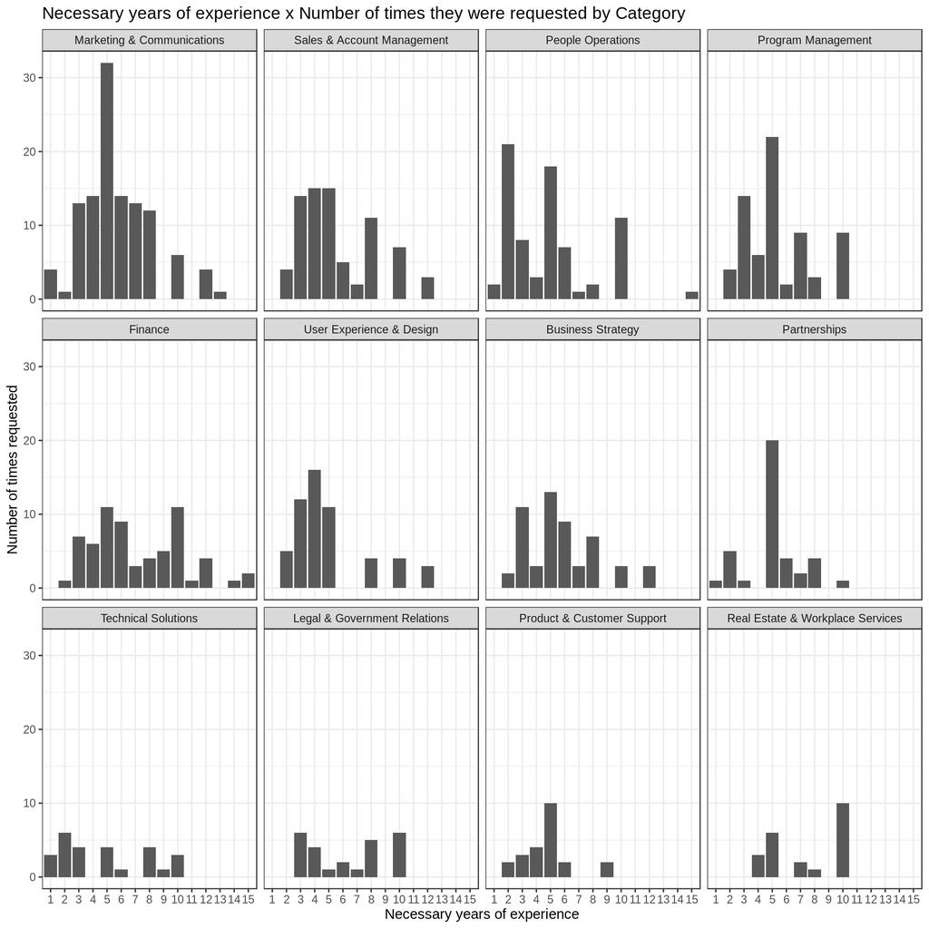

```r
# DataViz
ggplot(dfMinQualPlot, aes(x = reorder(dfMinQualPlot$necessaryYears, necessaryYears), y = dfMinQualPlot$numberOfTimes), fill = "category") +
  geom_bar(stat = 'identity') +
  xlab("Necessary years of experience") +
  ylab("Number of times requested") +
  ggtitle("Necessary years of experience x Number of times they were requested by Category") +
  theme_bw() +
  facet_wrap(.~ category, nrow = 3)
```

Percebe-se que áreas como Marketing e Sales mencionam anos de experiência mais vezes, enquanto áreas relacionadas à tecnologia, como Technical Solution (a única no top 12), mencionam pouco. De modo a olhar com mais cuidado para a questão, foi construída uma tabela, com as medianas dos anos de experiência por categoria:

```r
dfMinQualPlotMedian <- dfMinQualPlot %>%
  group_by(category) %>%
  summarise(median = median(necessaryYears)) %>%
  arrange(desc(median))
colnames(dfMinQualPlotMedian) <- c("Category", "Median")

formattable(dfMinQualPlotMedian)
```

| Category | Median |
| --- | --- |
| Finance | 8.0 |
| Real Estate & Workplace Services | 7.0 |
| Marketing & Communications | 6.0 |
| Sales & Account Management | 6.0 |
| Business Strategy | 6.0 |
| Legal & Government Relations | 6.0 |
| People Operations | 5.5 |
| Program Management | 5.5 |
| Partnerships | 5.5 |
| Technical Solutions | 5.5 |
| User Experience & Design | 5.0 |
| Product & Customer Support | 4.5 |

Levantou-se a hipótese de que as áreas Tech se comunicam de outra maneira com seus candidatos e que a experiência necessária seja requisitada através de outros recursos.

O caminho mais lógico é verificar as habilidades mínimas necessárias, o que nos leva à próxima etapa da análise.

## Áreas da Tecnologia

```r
# Necessary library for DataViz
library(wordcloud2)

# All of the categories
areas <- unique(df$category)

# Only technological categories
techAreas <- c("Technical Solutions" ,"Hardware Engineering" ,"Software Engineering","Data Center & Network","Technical Infrastructure", "IT & Data Management","Network Engineering")

# Subsetting dataset based on Tech categories
dfMinQualTech <- dfMinQual[dfMinQual$category %in% techAreas,]

# Data cleaning
dfMinQualTech$minimumQualifications <- str_replace_all(dfMinQualTech$minimumQualifications, ",", " ")
dfMinQualTech$minimumQualifications <- str_replace_all(dfMinQualTech$minimumQualifications, "\\.", " ")
```

De modo a elencar quais linguagens de programação foram requisitadas é necessário fazer um levantamento de todas as linguagens disponíveis, para evitar a exclusão de linguagens menos populares. Isso foi feito através do dataset criado pelo usuário @jamhall [https://github.com/jamhall/programming-languages-csv], que extraiu a lista de linguagens do Wikipedia.

```r
languages <- read_csv("~/Analysis/languages.csv")


# Applying REGEX
languages$name <- str_replace_all(languages$name, "\\/", "[\\\\/]")
languages$name <- str_replace_all(languages$name, regex("\\+"), "[\\\\+]")
languages$name <- str_replace_all(languages$name, "\\#", "[\\\\#]")
languages$name <- str_replace_all(languages$name, "\\!", "[\\\\!]")
languages$name <- str_replace_all(languages$name, "\\.", "[\\\\.]")
languages$name <- str_replace_all(languages$name, "\\(", "[\\\\(]")
languages$name <- str_replace_all(languages$name, "\\)", "[\\\\)]")
languages$name <- str_replace_all(languages$name, "\\-", "[\\\\-]")
languages$name <- str_replace_all(languages$name, "\\@", "[\\\\@]")
techLanguages <- paste(languages$name, collapse = "[,\\s\\)])|(\\b")
techLanguages <- paste0("(\\b",techLanguages,"[,\\s\\)])")

# Extracting programming languages into a new column
dfMinQualTech$languages <- str_extract_all(dfMinQualTech$minimumQualifications, regex(techLanguages, ignore_case = FALSE))

# Unlisting and cleaning the results
requiredLanguages <- unnest(dfMinQualTech, languages)
requiredLanguages$languages <- str_remove_all(requiredLanguages$languages, "\\)")
requiredLanguages$languages <- str_replace_all(requiredLanguages$languages, " ", "")
requiredLanguages <- requiredLanguages[-which(requiredLanguages$languages == "D"|requiredLanguages$languages == "T"),]

# Preparring dataset for DataViz
requiredLanguagesGraph <- requiredLanguages %>%
  select(category, languages) %>%
  group_by(category, languages) %>%
  add_tally() %>%
  unique()
```

```r
requiredLanguagesWordcloud <- requiredLanguages %>%
  select(languages) %>%
  group_by(languages) %>%
  add_tally() %>%
  unique()

wordcloud2(requiredLanguagesWordcloud)
```

[interactive chart not shown]

De um modo geral, grande parte das áreas pede 3 principais linguagens: Python, Java e C++.

Ainda seria necessário avaliar quais linguagens têm correlação entre si, mas a tendência é que as 3 mencionadas acima ocorram simultaneamente na maioria das vagas.

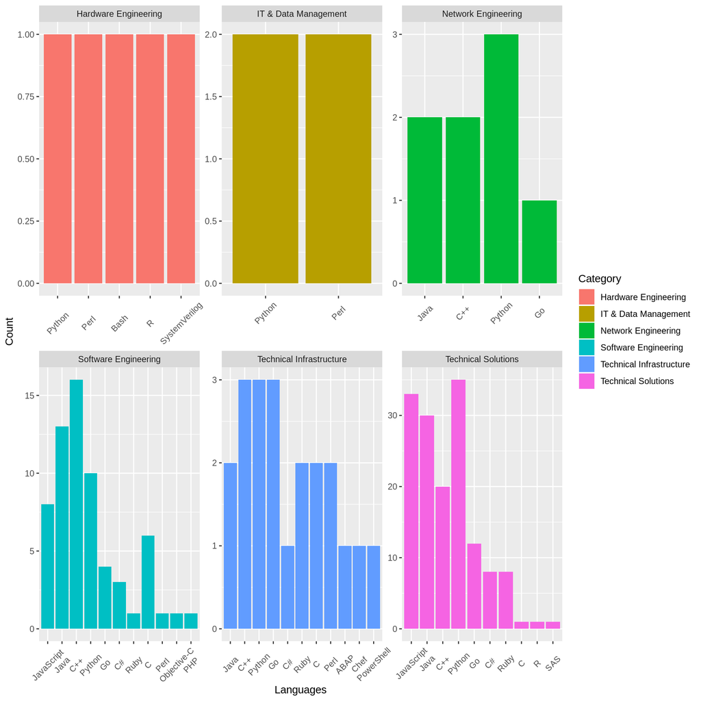

```r
ggplot(requiredLanguagesGraph, aes(x = reorder(languages, -n), y = n, fill = category)) +
  geom_bar(stat = 'identity', position = 'dodge') +
  xlab("Languages") +
  ylab("Count") +
  labs(fill = "Category") +
  theme(axis.text.x = element_text(angle = 45, vjust = 0.5) ) +
  facet_wrap(~category, scales = 'free')
```

Observando mais a fundo, os 3 primeiros gráficos representam áreas que não contêm tanta representatividade quanto as dos outros, seja por conta da menor disponibilidade de vagas, seja pelo menor número de linguagens pedidas.

## Conclusões e considerações finais

Com base nas informações exploradas acima, é interessante considerar a criação de uma *escala de experiência*. Por vezes, a experiência é quantificada em anos, em outras em grau de escolaridade. No caso de vagas mais técnicas, os requisitos vão desde linguagens a tipos específicos de infraestrutura.

A lógica de *rankeamento* em níveis de experiência ajuda a diversificar o processo seletivo e não prende a empresa em conjuntos de pré-requisitos específicos, o que pode se tornar ineficiente quando se trata de vagas com requisitos mais maleáveis.

Após esta análise exploratória, seria interessante considerar uma análise de correlação entre as linguagens e aprofundar o raciocínio através de outros recortes, como país, responsabilidades e posição. Assim, seria possível identificar oportunidades acionáveis em todas as variáveis, encontrando a relação entre cada grupo de características.

*Todo código está disponível ao clicar nos botões “Code” de cada seção*

–